# BikeEpiDemo

Jason Vargo

April 6, 2018

## Set up

The first thing you will need to do is tell R where to find the data, and to load or install the packages you will need to run the scripts. I prefer to work with R through [R Studio](https://www.rstudio.com/products/RStudio/).

```r
setwd(dir = "E:/Bicycle Epi/from Tom/") # this sets the working direcetory for your work, I am working from a thumb drive
library(tidyverse) # this is a great all around package for manipulating, clean, wrangling and vizualizing data
library("survey") # this is a package that Tom used to conduct the analysis of survey data
# install.packages("survey") the survey package is not one I use much so you may need to install it
```

## Load Tom’s Functions

Now we’ll load the functions that Tom wrote to process various parts of the data. Functions generally follow a form of

```
'nameOfTheFunction' <- function('variablesUsedInTheFunction'){

  ...
  code, code, code
  ...

     return('theResultsOfTheFunction')
 }
```

Here I am loading four of Tom’s functions into memory. The four are called:

- get.total.participation
- get.injury.agegroup.10yr
- get.survey.object.10yr
- get.large.dataset

These functions mostly process the [NEISS](https://www.cpsc.gov/Research--Statistics/NEISS-Injury-Data) sample to create estimates and group them by age and year consistent with the participation data, and then bring them together.

As you read through these functions you can see that they are nested and that some of the functions call other functions. At the end of this we’ll only call the `get.total.participation` function but we have to load all four because of these dependencies.

```r
get.total.participation<-function(x,y){

  #call function to get raw numbers of injuries in 10 year intervals
  raw.num.table<-t(get.injury.agegroup.10yr(x))
  raw.num.table<-raw.num.table[-(length(rownames(raw.num.table))),]

  #calculate incidence
  participation<-t(y)

  #get data frame with incidence statistics in ggplot format
  data.frame=assign("dataframe", NULL, envir = .GlobalEnv)
  year<-as.data.frame(c(1997:2013))
  for (i in 1:length(colnames(raw.num.table))){
    age.group<-as.character(rep(colnames(raw.num.table)[i],17))
    injuries<-raw.num.table[,i]
    participation.loop<-as.numeric(participation[,i])
    data.frame.loop<-as.data.frame(cbind(year,age.group,as.numeric(injuries),participation.loop))
    data.frame<-rbind(data.frame,data.frame.loop)
  }
  data.frame[,1]<-as.factor(data.frame[,1])
  colnames(data.frame)<-c("Year","AgeGroup","Injuries","Participants")

  #sort by year
  #data.frame<-data[order(data$Year),]

  #data.frame[,"AgeGroup"]<-as.character(data.frame[,"AgeGroup"])

  return(data.frame)
}
```

```r
get.injury.agegroup.10yr<-function(x){
  library(survey)

  #get survey object
  svyobj<-get.survey.object.10yr(x)

  #svytotals
  obj<-svyby(~num,~years+age_group,svytotal,design=svyobj)              # total injury number by year

  year<-c(1997:2013)
  range<-as.factor(c((rep("18-24",7)),(rep("25-34",10)),(rep("35-44",10)),(rep("45-54",10)),(rep("55-64",10)),(rep("65-74",10)),(rep("75-100",25))))

  data.frame=assign("dataframe", NULL, envir = .GlobalEnv)                                        #initialize data frame
  for (i in 0:6){
    count<-c(((17*i)+1):((17*i)+17))
    data.by.age.group<-obj[count,3]
    data.frame<-rbind(data.frame,data.by.age.group)
  }

  #add class
  class<-c(1,1,1,2,2,2,2)
  data.frame<-cbind(data.frame,class)

  colnames(data.frame)<-c(as.character(c(1997:2013)),"class")
  rownames(data.frame)<- as.character(c("18-24","25-34","35-44","45-54","55-64","65-74","75-105"))

  return(data.frame)
}
```

```r
get.survey.object.10yr<-function(x){
  library(survey)
  comb<-get.large.dataset(x)

  #survey design
  svyobj<-svydesign(id=~psu,strata=~stratum,weights=~weight,data=comb)

  #updating admission data
  svyobj<-update(svyobj,admitted=(disposition==4))
  svyobj<-update(svyobj,death=(disposition==8))
  svyobj<-update(svyobj,treated_released=(disposition==1))

  #updating race info
  svyobj<-update(svyobj,is_white=(race==1))
  svyobj<-update(svyobj,is_black=(race==2))
  svyobj<-update(svyobj,is_asian=(race==4))
  svyobj<-update(svyobj,is_other_race=(race==3 | race==5 | race==6 |race==4 & race!=0))
  svyobj<-update(svyobj,race_not_listed=(race==0))

  # update gender stuff
  svyobj<-update(svyobj,is_male=(sex==1))

  #update body part
  svyobj<-update(svyobj,head_inj=(body_part==75))
  svyobj<-update(svyobj,torso_inj=(body_part==31 | body_part==79))
  svyobj<-update(svyobj,extrem_inj=(body_part==30 | body_part==32 | body_part==33 | body_part==34 | body_part==35 | body_part==36 | body_part==37 | body_part==80 | body_part==81 | body_part==82 | body_part==83 | body_part==92 | body_part==93))
  svyobj<-svyobj<-update(svyobj,other_inj=(body_part!=75 & body_part!=31 & body_part!=79 & body_part!=30 & body_part!=32 & body_part!=33 & body_part!=34 & body_part!=35 & body_part!=36 & body_part!=37 & body_part!=80 & body_part!=81 & body_part!=82 & body_part!=83 & body_part!=92 & body_part!=93))

  #adding year
  svyobj<-update(svyobj,years=cut(year,c(1997,1998,1999,2000,2001,2002,2003,2004,2005,2006,2007,2008,2009,2010,2011,2012,2013,2014),right=FALSE))

  #adding age group
  svyobj<-update(svyobj,age_group=(cut(age,c(18,25,35,45,55,65,75,Inf),right=FALSE)))
  return(svyobj)
}
```

```r
get.large.dataset<-function(x){
  dataframe.big<-assign("data.frame", NULL, envir = .GlobalEnv)
  row.all<-assign("data.frame",NULL,envir=.GlobalEnv)
  for (i in 1:length(x)){
    dataframe=as.data.frame(x[[i]])
    year<-rep(1996+i,length(rownames(dataframe)))
    num<-as.integer(rep(1,length(rownames(dataframe))))
    dataframe.small<-cbind(dataframe,year,num)
    colnames<-c("Case","trmt_date","psu","weight","stratum","age","sex","race","race_other","diag","diag_other","body_part","disposition","location","fmv","prod1","prod2","narr1","narr2","year","num")
    colnames(dataframe.small)<-colnames
    dataframe.big<-rbind(dataframe.big,dataframe.small)
  }
  return(dataframe.big)
}
```

## Load the data

Now we need to bring in the data and then we’ll process with the functions we’ve loaded. There are two datasets we need to look at: `adult.data` and `particitipation.data`. Both are saved on the thumbdrive as Rdata objects. Note that Tom’s participation file contains a spelling error in the filename, but is saved as an object with the correct spelling once brought into R (I think through the metadata that R can access). This is a characteristic of the data as Tom saved it, not something R figures out on its own.

```r
load("E:/Bicycle Epi/from Tom/adult.data.RData") # this command automatically save this data to an object called 'adult.data' that we can call
load("E:/Bicycle Epi/from Tom/particitipation.data.RData")

# adult <- readRDS("E:/Bicycle Epi/from Tom/adult.data.RData") # alternatively we could read in the data and send it to an object of whatever name we prefer, in this case 'adult'
```

## Investigate the Data

We can also examine the data. Let’s look at `participation.data`; `adult.data` is the survey data and is structured in lists so it is a bit trickier to look at.

```r
head(participation.data) # here we see the firt 10 rows of the 'participation.data' - note there are only 7
```

```
##          1997    1998    1999    2000    2001    2002    2003    2004
## 18-24 4466781 3569870 3477292 3709610 2847292 3186799 2646761 3104409
## 25-34 6542255 7052670 6148870 6383980 5460560 5876954 5148494 5644380
## 35-44 7309278 7313880 7378644 6815330 6825700 6994403 6054919 6007233
## 45-54 3609520 3874615 4070976 4529175 3471356 4304248 3879499 4394553
## 55-64 1849879 2046145 1823458 2199885 1755180 2193511 1776593 2338386
## 65-74 1037737 1131910  890526 1164645 1053108 1117449 1015196 1128876
##          2005    2006    2007    2008    2009    2010    2011    2012
## 18-24 3709868 2030397 4376385 3290095 3051120 3859533 3275870 4104181
## 25-34 5521664 4630730 4750435 4644840 5339460 4814469 4512558 5070650
## 35-44 6772666 6019949 5685560 5922171 6941298 6087717 5219943 6157868
## 45-54 5564802 4381383 4638220 5070617 4843653 4933836 5758943 5704057
## 55-64 2286314 2778438 2543540 2593369 2860425 3421854 4157032 4534326
## 65-74 1466692 1175493 1159555 1122503 1334865 1313037 1624428 2101731
##          2013
## 18-24 3260421
## 25-34 4807556
## 35-44 5587133
## 45-54 4742554
## 55-64 4172702
## 65-74 2146101
```

```r
names(participation.data) # see the column names of the table
```

```
##  [1] "1997" "1998" "1999" "2000" "2001" "2002" "2003" "2004" "2005" "2006"
## [11] "2007" "2008" "2009" "2010" "2011" "2012" "2013"
```

It looks like the rows are named for the age group that they represent and each column is a year. We can restructure this into a more tidy (long, instead of wide) format if we want, but I know Tom’s functions will expect it in its current format.

Don’t worry too much about the syntax here, it is more to illustrate some of the functionality or R and the tidyverse (and only relies on a package called ‘DT’ for the cleaner presentation of the table).

```r
years <- names(participation.data)

DT::datatable({
  participation.data %>%
    mutate(age = row.names(.)) %>%
    gather(years, key = "year", value = "participation")
})
```

|  | age | year | participation |
| --- | --- | --- | --- |
| 1 | 18-24 | 1997 | 4466781 |
| 2 | 25-34 | 1997 | 6542255 |
| 3 | 35-44 | 1997 | 7309278 |
| 4 | 45-54 | 1997 | 3609520 |
| 5 | 55-64 | 1997 | 1849879 |
| 6 | 65-74 | 1997 | 1037737 |
| 7 | 75+ | 1997 | 541428 |
| 8 | 18-24 | 1998 | 3569870 |
| 9 | 25-34 | 1998 | 7052670 |
| 10 | 35-44 | 1998 | 7313880 |

[output cut: 109 more lines]

## Running the function

We’re now going to run the `get.total.participation` function. See above to recall that it expects two inputs (`x` and `y`). `x` will be the `adult.data` and `y` will be the `participation.data`. We’ll return the output of the function, a table that has four coulmns [Year, AgeGroup, Injuries, Participants] to an object we’ll call `plot.data`. And we’ll look at the data.

```r
plot.data <- get.total.participation(adult.data,participation.data)

DT::datatable(plot.data)
```

|  | Year | AgeGroup | Injuries | Participants |
| --- | --- | --- | --- | --- |
| 1 | 1997 | 18-24 | 43822.6329 | 4466781 |
| 2 | 1998 | 18-24 | 49916.3974 | 3569870 |
| 3 | 1999 | 18-24 | 43914.7105 | 3477292 |
| 4 | 2000 | 18-24 | 48811.5485 | 3709610 |
| 5 | 2001 | 18-24 | 50635.2153 | 2847292 |
| 6 | 2002 | 18-24 | 43695.7668 | 3186799 |
| 7 | 2003 | 18-24 | 40922.8622 | 2646761 |
| 8 | 2004 | 18-24 | 43449.4927 | 3104409 |
| 9 | 2005 | 18-24 | 43828.6646 | 3709868 |
| 10 | 2006 | 18-24 | 45788.6438 | 2030397 |

[output cut: 109 more lines]

## Plot the data

Lastly, we’ll plot the data using one of the most popular packages in R called [ggplot2](http://r4ds.had.co.nz/data-visualisation.html). The syntax is a bit weird (it follows something called the Grammar of Graphics) but you get used to it.

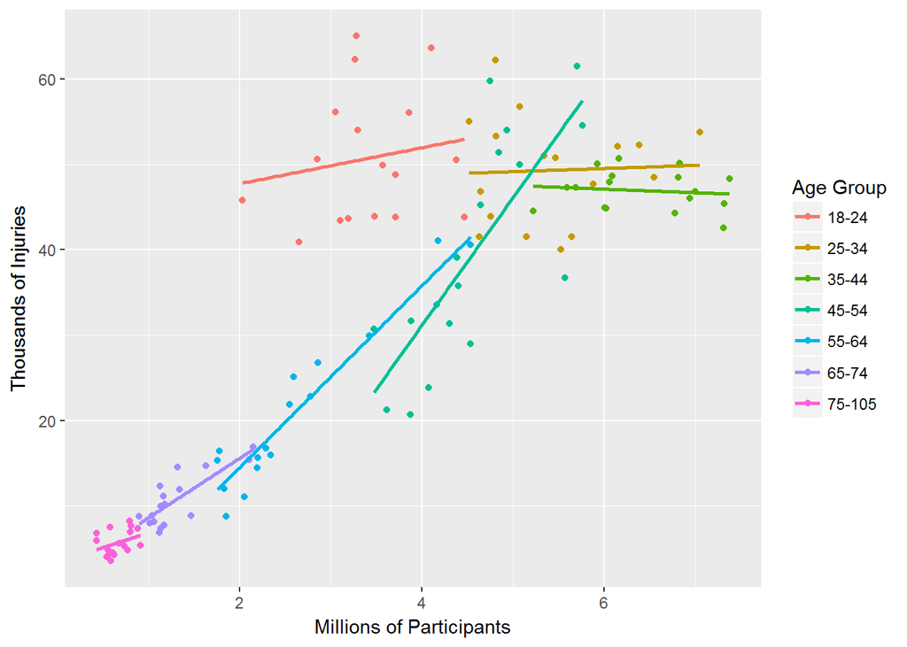

```r
# in the first part of this we'll tell ggplot which dataset to use, and what variables to use for x,y, color, and size, transparency, etc.

ggplot(plot.data, aes(Participants/1000000,Injuries/1000, color=factor(AgeGroup))) +
  geom_point(stat="identity") + # we want to plot the points based on data we described in the first ggplot part
  geom_smooth(method=lm, se=FALSE) + # we also want linear estimates for each age group
  xlab("Millions of Participants") + # the rest of these are for customizing the labels
  ylab("Thousands of Injuries") +
  scale_color_discrete(name = "Age Group")
```

## Extra, create a dynamic plot

We can get as fancy as we want with this.

```r
library(plotly)

plot_ly(
  data = plot.data,
  x = ~ round(Participants / 1000000,1),
  y = ~ round(Injuries / 1000,1),
  type = "scatter",
  mode = "markers",
  text = plot.data[["Year"]],
  color = ~AgeGroup,
  showlegend = TRUE
) %>%
  layout(
    title = "Cyclist Injuries and Participation by Age",
    xaxis = list(
      title = "Millions of Participants",
      autotick = TRUE,
      ticks = "outside",
      tick0 = 0,
      dtick = 1,
      ticklen = 5,
      tickwidth = 2,
      tickcolor = toRGB("black")
    ),
    yaxis = list(
      title = "Thousands of Injuries",
      autotick = TRUE,
      ticks = "outside",
      tick0 = 0,
      dtick = 1,
      ticklen = 5,
      tickwidth = 2,
      tickcolor = toRGB("black")
    ))  %>%
  config(
    collaborate = FALSE,
    displaylogo = FALSE,
    modeBarButtonsToRemove = list(
      'toggleSpikelines',
      'sendDataToCloud',
      'hoverCompareCartesian',
      'zoom2d',
      'pan2d',
      'select2d',
      'lasso2d',
      'zoomIn2d',
      'zoomOut2d',
      'autoScale2d',
      'resetScale2d',
      'hoverClosestCartesian'
    ))
```

[interactive chart not shown]